# R Exercises - G(r,t)

2020-07-07

# 1 A bit of context

In this exercise, we will see how to make a color plot of $4\pi r^2\times G(r,t)$ data obtained from Molecular Dynamics simulations. These files can be downloaded here. These auto-correlators $G(r,t)$ are obtained from MD trajectories of a fluid encapsulated in a porous medium by computing the probability that each molecule moves by a distance $r$ over a time $t$. The MD trajectories are performed with [LAMMPS](https://lammps.sandia.gov/) and the trajectories treated by a home-made C program producing these files.

In these simulations, we varied the depth of the interaction well. It is given in the name of the file such as `Grt_xx.dat`, where xx = 0.01, 0.1, 0.2, 0.3, 0.5, 0.8, 1 corresponds to $\varepsilon/k_BT$. $\varepsilon/k_BT$ is the depth of the interaction well in units of temperature.

The `Grt_xx.dat` files contain the $4\pi r^2\times G(r,t)$ data under the form of a matrix, with $r$ increasing with the rows and $t$ with the columns. $r$ goes from 0 to 20 Å and $t$ goes from 0 to 200 ps.

# 2 Reading and tidying the data

We want to read all data files and store them into a tidy tibble for ease of plotting.

- Load the `tidyverse` and `ggplot2` packages
- Find all files starting by “Grt” and store them in a vector `Grt_files`
- Initiate an empty tibble `Grt` that will store all data
- Using a `for` loop:
  - read the files
  - add columns names as the times values
  - add the `r.A` column containing the r values
  - and recursively (using the pipe `%>%`)
    - pivot the table to make it tidy, with the columns `r.A`, `t.ps` and `r2Grt`
    - make sure that the times are read as numeric values
    - add the `epskt` column containing the $\varepsilon/k_BT$ value
  - store this in `Grt`

```r
library(tidyverse)
library(ggplot2)
Grt_files <- list.files(pattern = "Grt_", path="Data")
Grt       <- tibble()
for(Grt_file in Grt_files){#Grt_file <- Grt_files[1]
    d <- read_table(file.path("Data",Grt_file), col_names=FALSE)
    names(d) <- as.character(seq(0,200, length=ncol(d)))
    d$r.A    <- seq(0,20, length=nrow(d))
    eps <- gsub(".dat","",gsub("Grt_","",Grt_file))
    d <- d %>%
        pivot_longer(cols=-r.A,
                     names_to="t.ps",
                     names_transform=list(t.ps = as.numeric),
                     values_to="r2Grt") %>%
        mutate(epskt=as.numeric(eps))
    Grt <- bind_rows(Grt, d)
}
```

# 3 Plotting data

We should have a `Grt` dataset that looks like this:

```r
Grt
```

```
## # A tibble: 2,815,407 x 4
##      r.A  t.ps      r2Grt epskt
##    <dbl> <dbl>      <dbl> <dbl>
##  1     0   0   77.7        0.01
##  2     0   0.1  0.000512   0.01
##  3     0   0.2  0.000203   0.01
##  4     0   0.3  0.000148   0.01
##  5     0   0.4  0.0000979  0.01
##  6     0   0.5  0.0000817  0.01
##  7     0   0.6  0.0000714  0.01
##  8     0   0.7  0.0000683  0.01
##  9     0   0.8  0.0000687  0.01
## 10     0   0.9  0.0000552  0.01
## # … with 2,815,397 more rows
```

We will now plot this as a colored heatmap using `geom_raster` from `ggplot2`:

- We will first plot `Grt` only for times below 100 ps and $\varepsilon/k_BT=0.5$, so recursively filter the data accordingly, then provide this to `ggplot`
- Use a nicer axis labels
- Do you see anything on the plot?
- In fact, we need to saturate values above a certain limit in order to see the fine evolution of the $G(r,t)$ auto-correlator. Add a mutation of the tibble attributing the limit value to all points above this limit, and play with the limit value in order to have a nicer plot.
- Add a vertical dashed line in x=8.18Å marking the mean pore size for this structure.
- Use a nicer color scheme with more colors in order to better see the variations.

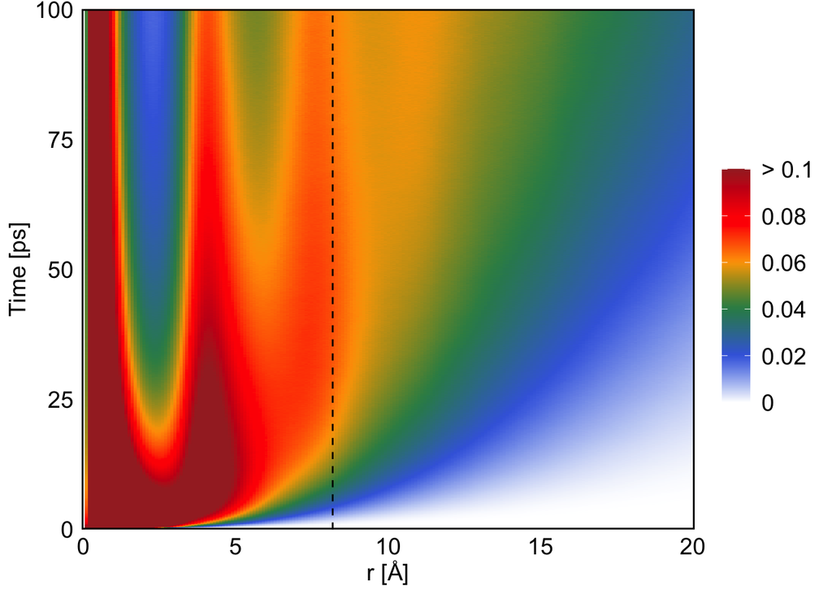

```r
lim    <- 0.1
nbreak <- 6
colors <- colorRampPalette(c("white","royalblue","seagreen","orange","red","brown"))(50)
Grt %>%
    filter(t.ps<=100, epskt==0.5) %>%
    mutate(r2Grt=ifelse(r2Grt>lim, lim, r2Grt)) %>%
    ggplot(aes(x=r.A, y=t.ps, fill=r2Grt))+
        geom_raster()+
        geom_vline(aes(xintercept=8.18), lty=2)+
        scale_fill_gradientn(
            colors = colors,
            name   = '',
            breaks = seq(0, lim, length=nbreak),
            labels = c(seq(0, lim, length=nbreak)[1:(nbreak-1)], paste(">",lim))
        ) +
        labs(x = "r [Å]", y="Time [ps]") +
        scale_x_continuous(expand = c(0,0)) +
        scale_y_continuous(expand = c(0,0))
```

Now we want to see the evolution of $G(r,t)$ as a function of $\varepsilon/k_BT$. Using the procedure above, plot $G(r,t)$ for all $\varepsilon/k_BT$ on a grid.

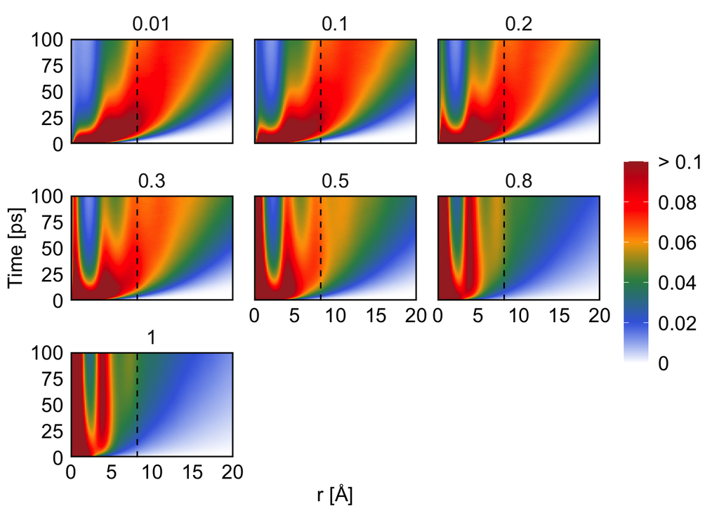

```r
lim    <- 0.1
nbreak <- 6
colors <- colorRampPalette(c("white","royalblue","seagreen","orange","red","brown"))(50)
Grt %>%
    filter(t.ps<=100) %>%
    mutate(r2Grt=ifelse(r2Grt>lim, lim, r2Grt)) %>%
    ggplot(aes(x=r.A, y=t.ps, fill=r2Grt))+
        geom_raster()+
        geom_vline(aes(xintercept=8.18), lty=2)+
        scale_fill_gradientn(
            colors = colors,
            name   = '',
            breaks = seq(0, lim, length=nbreak),
            labels = c(seq(0, lim, length=nbreak)[1:(nbreak-1)], paste(">",lim))
        ) +
        labs(x = "r [Å]", y="Time [ps]") +
        scale_x_continuous(expand = c(0,0)) +
        scale_y_continuous(expand = c(0,0)) +
        facet_wrap(~epskt)
```